# SQL for Data Science Capstone Project

Justas Mundeikis

# Data

This analysis is based on Olympic sports data ranging from 1896 to 2016. With over 66 different sport disciplines.

## Audiance

The audience of this report are Lithuanian basketball strategist, who are interested in knowing, if Lithuanian national basketball team is becoming “older”, “lower” and “older”? As some players return every 4 years to play again for their country. They want to know, if the competitiveness of the national team might decrease due to players physique.

## Hypotheses

I have raised following hypotheses:

1. Hypothesis average height **decreased** among Lithuanian players at Olympics in period 1992 vs 2016
2. Hypothesis average weight **increased** among Lithuanian players at Olympics in period 1992 vs 2016
3. Hypothesis average age **increased** among Lithuanian players at Olympics in period 1992 vs 2016

## Previous research

Exploratory data analysis can be found in [my GitHub repository](https://github.com/justasmundeikis/SQL_capstone)

## H1 Height

1. Hypothesis average height **decreased** among Lithuanian players at Olympics in period 1992 vs 2016

The Box plot diagram shows that the median has slightly increased over time, while the variation has decreased when comparing to 1996-2004 era.

## H1 Height

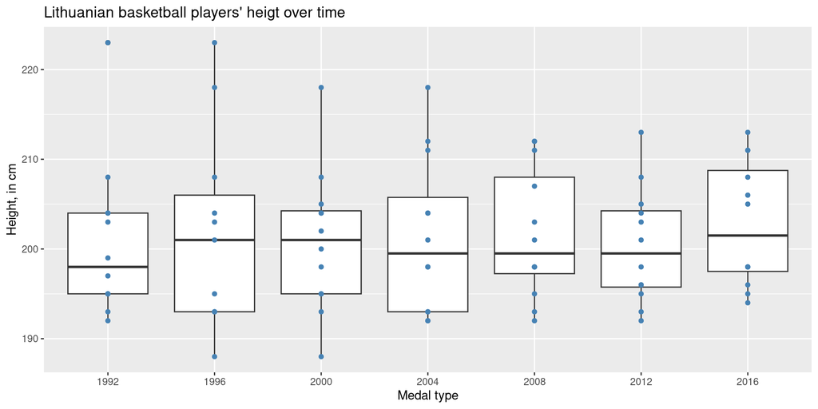

## H1 Height

Summary statistics table:

Summary statistics

Lithuanian Basketball players

| Year | avg_height | sd_height | median_height |
| --- | --- | --- | --- |
| 1992 | 200.7 | 8.7 | 198.0 |
| 1996 | 201.7 | 11.1 | 201.0 |
| 2000 | 200.8 | 7.9 | 201.0 |
| 2004 | 201.3 | 8.7 | 199.5 |
| 2008 | 201.7 | 7.3 | 199.5 |
| 2012 | 200.3 | 6.4 | 199.5 |
| 2016 | 202.8 | 7.0 | 201.5 |

This data may suggest, that the hypothesis will be rejected.

## H2 Weight

2. Hypothesis average weight **increased** among Lithuanian players at Olympics in period 1992 vs 2016

The Boxplot diagram shows that the median weight has slightly increased over time, while the variation has remain approximately the same over time.

## H2 Weight

[figure not shown]

## H2 Weight

Summary statistics table:

Summary statistics

Lithuanian Basketball players

| Year | avg_weight | sd_weight | median_weight |
| --- | --- | --- | --- |
| 1992 | 100.4 | 11.5 | 95.0 |
| 1996 | 100.6 | 12.9 | 96.0 |
| 2000 | 98.6 | 12.7 | 98.5 |
| 2004 | 100.2 | 9.8 | 97.5 |
| 2008 | 100.5 | 9.9 | 99.0 |
| 2012 | 99.4 | 12.2 | 99.0 |
| 2016 | 100.8 | 12.5 | 100.5 |

This data may suggest, that the hypothesis will be confirmed

## H3 Age

3. Hypothesis average age **increased** among Lithuanian players at Olympics in period 1992 vs 2016

The Box plot diagram shows that in 1922 there was the largest variation in data, then in 1996 the median age dropped and every games past that more or less the same players returned to Olympics, the median age increased. In 2016, although completely different players were playing, the median variation appears to be very similar to 1996

## H3 Age

[figure not shown]

## H3 Age

Summary statistics

Lithuanian Basketball players

[output not shown]

## Hypotheses testing

Despite exploratory data analysis showing some relative increases in basketball players physique - none of it appears to be significant

Lithuanian basketball players metrics 1992 vs 2016

student-t statiscis for height, weight, age

| variable | estimate1 | estimate2 | rel_change | p.value |
| --- | --- | --- | --- | --- |
| Age | 27.33 | 27.75 | 1.52% | 0.841 |
| Height | 200.67 | 202.75 | 1.04% | 0.523 |
| Weight | 100.42 | 100.75 | 0.33% | 0.946 |

## Conclusions

Lithuanian basketball strategists can be calmed down, despite some players returning to play for their country, the national team does not become older, heavier and does not loose height. Thus competitiveness of national team will depend on skills and not on physique.